# RT-qPCR analysis sample

Atsushi Hara

## 1. ライブラリーを読み込む

```r
library(tidyverse)
```

## 2. サンプル情報を設定

発現量の基準にするサンプル番号 (standard), サンプルの群情報 (group)を設定

```r
standard <- 1
group <- factor(c(0,0,1,0,0,1,1,1,0,0,1,0,1,0),levels=c(0,1))
levels(group) <- c("WT","KO")
```

## 3. サンプルを読み込む

csvにしたRT-qPCRデータを読み込む (最初の７行はいらないので飛ばす)

```r
tb <- read_csv("sample2.csv", skip=7)
tb
```

[output not shown]

[output cut: 79 more lines]

## 4. データを加工する

### 前処理

1. 前のtableから2, 3, 10列目 (サンプル番号, ターゲット遺伝子, Ct値)を抜き出す (select)
2. 一番下に要らない行があるので除く (drop_na)
3. 列の名前を変更 (colnames() <- )

```r
tb2 <- tb %>%
  select(2,3,10) %>%
  drop_na()

colnames(tb2) <- c("sample","target","Ct")
```

### Ct値を発現量に変換してreplicateの平均を取る

1. サンプル番号を数字に変える (ex: Sample 1 → 1)
2. Ct値を発現量に変換 (expression = 2**(-Ct))
3. Ct値は要らなくなったので、Ct値の列を落とす (-Ct)
4. サンプル番号, ターゲット遺伝子でグループ化する (replicateがグループになる)
5. replicateの中で発現量の平均を取る (mean(expression))

```r
tb2 <- tb2 %>%
  mutate(sample=parse_number(sample)) %>%
  mutate(expression=2**(-Ct)) %>%
  select(-Ct) %>%
  group_by(sample,target) %>%
  summarize(expression=mean(expression)) %>%
  ungroup()
tb2
```

| sample | target | expression |
| --- | --- | --- |
| 1 | gapdh | 2.938596e-06 |
| 1 | il1b | 2.111816e-08 |
| 1 | il6 | 2.361102e-08 |
| 1 | setdb2_754 | 2.212478e-08 |
| 1 | tnfa | 2.002313e-08 |
| 2 | gapdh | 6.239465e-06 |
| 2 | il1b | 5.990769e-07 |
| 2 | il6 | 2.463649e-07 |
| 2 | setdb2_754 | 6.559299e-08 |
| 2 | tnfa | 1.342657e-07 |

[output cut: 60 more lines]

### 整理して群情報をつける

1. target列の値を列名にして表を横に広げる (pivot_wider)
2. sample順に並べ替える (arrange)
3. group列に群情報を追加する (mutate)

```r
tb3 <- tb2 %>%
  pivot_wider(names_from = target, values_from=expression) %>%
  arrange(sample) %>%
  mutate(group=group)
tb3
```

| sample | gapdh | il1b | il6 | setdb2_754 | tnfa | group |
| --- | --- | --- | --- | --- | --- | --- |
| 1 | 2.938596e-06 | 2.111816e-08 | 2.361102e-08 | 2.212478e-08 | 2.002313e-08 | WT |
| 2 | 6.239465e-06 | 5.990769e-07 | 2.463649e-07 | 6.559299e-08 | 1.342657e-07 | WT |
| 3 | 7.302799e-06 | 6.873434e-07 | 2.813361e-07 | 7.778779e-08 | 1.586226e-07 | KO |
| 4 | 4.488080e-06 | 8.471410e-08 | 8.168438e-07 | 9.282666e-08 | 4.041891e-08 | WT |
| 5 | 7.482920e-06 | 1.185031e-06 | 8.353674e-07 | 1.147966e-07 | 2.046207e-07 | WT |
| 6 | 5.507594e-06 | 1.608680e-07 | 6.311615e-08 | 3.032706e-08 | 1.100273e-08 | KO |
| 7 | 5.671977e-06 | 1.819804e-07 | 1.648212e-07 | 9.886858e-08 | 6.032519e-08 | KO |
| 8 | 5.826880e-06 | 1.430567e-07 | 5.319476e-08 | 3.012772e-08 | 4.602057e-08 | KO |
| 9 | 6.792687e-06 | 1.798051e-07 | 1.120475e-07 | 3.621671e-08 | 3.033448e-08 | WT |
| 10 | 6.487527e-06 | 6.479898e-08 | 7.711292e-09 | 4.336451e-08 | 1.490295e-08 | WT |

[output cut: 4 more lines]

### gapdhで発現量を補正する

1. sample, group, gapdh列以外を選択する (select)  
   gapdh以外の遺伝子の発現量を抽出
2. 各遺伝子の発現量をgapdhの発現量で割る (mutate_all)
3. sample, group列とgapdhで補正した各遺伝子の発現量の表を結合する (cbind)

```r
expression <- tb3 %>%
  select(!c(sample,gapdh,group)) %>%
  mutate_all(function(x){return(x/tb3$gapdh)})
expression2 <- cbind(tb3 %>% select(sample,group),expression)
expression2
```

| sample | group | il1b | il6 | setdb2_754 | tnfa |
| --- | --- | --- | --- | --- | --- |
| 1 | WT | 0.007186480 | 0.008034798 | 0.007529030 | 0.006813843 |
| 2 | WT | 0.096014157 | 0.039484950 | 0.010512599 | 0.021518793 |
| 3 | KO | 0.094120546 | 0.038524423 | 0.010651778 | 0.021720796 |
| 4 | WT | 0.018875353 | 0.182002946 | 0.020682931 | 0.009005835 |
| 5 | WT | 0.158364797 | 0.111636551 | 0.015341151 | 0.027345028 |
| 6 | KO | 0.029208396 | 0.011459840 | 0.005506408 | 0.001997738 |
| 7 | KO | 0.032084127 | 0.029058864 | 0.017431060 | 0.010635655 |
| 8 | KO | 0.024551161 | 0.009129201 | 0.005170473 | 0.007897977 |
| 9 | WT | 0.026470399 | 0.016495316 | 0.005331722 | 0.004465755 |
| 10 | WT | 0.009988241 | 0.001188634 | 0.006684290 | 0.002297170 |

[output cut: 4 more lines]

### standardの発現が1.0になるように補正する

sample, group列を除いて、standardの発現量で割る (x/x[standard])

```r
expression3 <- expression2 %>%
  mutate_at(-c(1,2),function(x){return(x/x[standard])})
expression3
```

| sample | group | il1b | il6 | setdb2_754 | tnfa |
| --- | --- | --- | --- | --- | --- |
| 1 | WT | 1.000000 | 1.0000000 | 1.0000000 | 1.0000000 |
| 2 | WT | 13.360387 | 4.9142431 | 1.3962753 | 3.1580991 |
| 3 | KO | 13.096891 | 4.7946972 | 1.4147609 | 3.1877451 |
| 4 | WT | 2.626509 | 22.6518385 | 2.7470909 | 1.3216968 |
| 5 | WT | 22.036490 | 13.8941329 | 2.0375998 | 4.0131577 |
| 6 | KO | 4.064354 | 1.4262760 | 0.7313568 | 0.2931882 |
| 7 | KO | 4.464512 | 3.6166266 | 2.3151799 | 1.5608893 |
| 8 | KO | 3.416298 | 1.1362078 | 0.6867382 | 1.1591075 |
| 9 | WT | 3.683361 | 2.0529846 | 0.7081552 | 0.6553945 |
| 10 | WT | 1.389866 | 0.1479357 | 0.8878022 | 0.3371328 |

[output cut: 4 more lines]

## 5. グラフ化する準備

遺伝子名をtarget、発現量をexpressionとして表を縦に伸ばす (pivot_longer)

```r
expression4 <- expression3 %>%
  pivot_longer(!c(sample,group),names_to="target",values_to="expression")
expression4
```

| sample | group | target | expression |
| --- | --- | --- | --- |
| 1 | WT | il1b | 1.0000000 |
| 1 | WT | il6 | 1.0000000 |
| 1 | WT | setdb2_754 | 1.0000000 |
| 1 | WT | tnfa | 1.0000000 |
| 2 | WT | il1b | 13.3603870 |
| 2 | WT | il6 | 4.9142431 |
| 2 | WT | setdb2_754 | 1.3962753 |
| 2 | WT | tnfa | 3.1580991 |
| 3 | KO | il1b | 13.0968907 |
| 3 | KO | il6 | 4.7946972 |

[output cut: 46 more lines]

## 6. グラフ化

### 1. サンプルごとの発現量

1. 縦に伸ばした発現量の表をグラフ化 (data=expression4)
2. targetごとにグラフを分ける (facet_wrap)
3. xにサンプル番号、yに発現量を割り当てて棒グラフにする (geom_bar)  
   グラフは積み上げずに分ける (stat=“identity”)

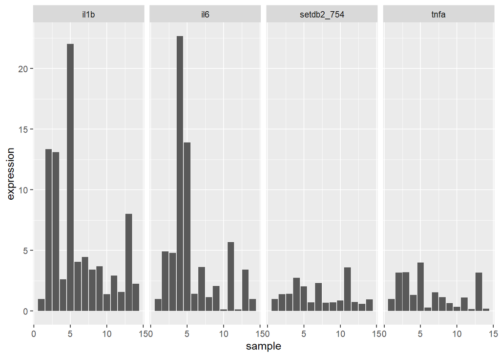

```r
ggplot(data=expression4) +
  facet_wrap(.~target,ncol=5) +
  geom_bar(aes(x=sample,y=expression),stat="identity")
```

### 2. 群内での各統計量を求める

1. target, groupでグループ化
2. 各グループ内で平均 (mean), 標準偏差 (sd), 標準誤差 (se), 最大値 (max), 最小値 (min)を求める

```r
expression.summary <- expression4 %>%
  group_by(target,group) %>%
  summarize(mean=mean(expression),sd=sd(expression),se=sd(expression)/sqrt(length(expression)),max=max(expression),min=min(expression))
expression.summary
```

| target | group | mean | sd | se | max | min |
| --- | --- | --- | --- | --- | --- | --- |
| il1b | WT | 5.988495 | 7.6354475 | 2.6995383 | 22.036490 | 1.0000000 |
| il1b | KO | 5.999273 | 3.9131399 | 1.5975327 | 13.096891 | 2.9400615 |
| il6 | WT | 5.724472 | 8.2324604 | 2.9106143 | 22.651838 | 0.1270969 |
| il6 | KO | 3.343022 | 1.7997134 | 0.7347299 | 5.680759 | 1.1362078 |
| setdb2_754 | WT | 1.312212 | 0.7235074 | 0.2557985 | 2.747091 | 0.7081552 |
| setdb2_754 | KO | 1.556918 | 1.1937666 | 0.4873532 | 3.598177 | 0.5952946 |
| tnfa | WT | 1.355444 | 1.4509261 | 0.5129798 | 4.013158 | 0.1576063 |
| tnfa | KO | 1.745316 | 1.1833827 | 0.4831140 | 3.187745 | 0.2931882 |

### 3. 各群の発現量平均をグラフ化

1. 各統計量の表をグラフ化 (expression.summary)
2. targetでグラフを分ける (facet_wrap)
3. xを群、yを各群の発現量平均として棒グラフにする (geom_bar)

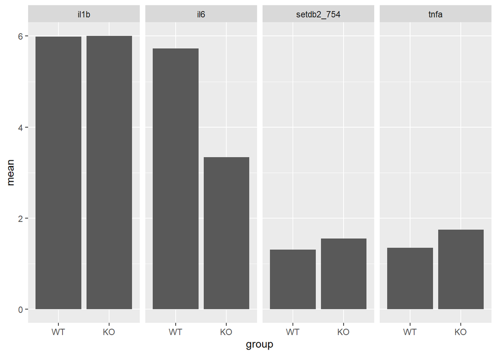

```r
ggplot(expression.summary) +
  facet_wrap(.~target,ncol=5) +
  geom_bar(aes(x=group,y=mean),stat="identity")
```

### 4. 3のグラフにエラーバーをつける

1. 各統計量の表をグラフ化 (expression.summary)
2. targetでグラフを分ける (facet_wrap)
3. xを群、yを各群の発現量平均として棒グラフにする (geom_bar)
4. 平均±標準誤差をymin, ymaxに割り当ててエラーバーを描く (geom_errorbar)

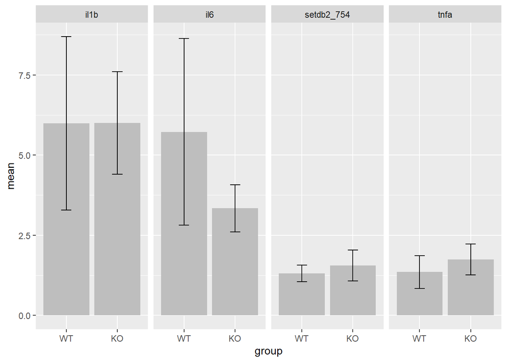

```r
ggplot(expression.summary) +
  facet_wrap(.~target,ncol=5) +
  geom_bar(aes(x=group,y=mean),stat="identity",fill="grey") +
  geom_errorbar(aes(x=group,ymin=mean-se,ymax=mean+se),width=0.2)
```

### 5. t検定の結果をグラフにする (ちょっとむずい)

#### t検定をする (描画用のパラメータも出す)

1. sample列以外を選択
2. 群を列名として表を横に開く (pivot_wider)  
   重複する値はリストになる
3. target列でグループ化
4. 群間でt検定してp値を出す (t.test)  
   群内の発現量最大/最少を出す
5. 各遺伝子で最大の発現量 (max.max), 群内の発現量平均で最大のもの (max.mean)を出す  
   p値を小数点2桁までにする (round)

```r
test <- expression4 %>%
  select(-sample) %>%
  pivot_wider(names_from = group,values_from = expression,values_fn=list) %>%
  group_by(target) %>%
  mutate(ttest=t.test(unlist(WT),unlist(KO))$p.value) %>%
  summarize(WT.max=max(unlist(WT)),KO.max=max(unlist(KO)),WT.mean=mean(unlist(WT)),KO.mean=mean(unlist(KO)),ttest=ttest) %>%
  group_by(target) %>%
  mutate(max.max=max(WT.max,KO.max),max.mean=max(WT.mean,KO.mean), ttest=round(ttest,digits=2))
test
```

| target | WT.max | KO.max | WT.mean | KO.mean | ttest | max.max | max.mean |
| --- | --- | --- | --- | --- | --- | --- | --- |
| il1b | 22.036490 | 13.096891 | 5.988495 | 5.999273 | 1.00 | 22.036490 | 5.999273 |
| il6 | 22.651838 | 5.680759 | 5.724472 | 3.343022 | 0.45 | 22.651838 | 5.724472 |
| setdb2_754 | 2.747091 | 3.598177 | 1.312212 | 1.556918 | 0.67 | 3.598177 | 1.556918 |
| tnfa | 4.013158 | 3.187745 | 1.355444 | 1.745316 | 0.59 | 4.013158 | 1.745316 |

#### 箱ひげ図を描く

1. expression4を使い、xを群、yを発現量とする
2. ターゲット遺伝子ごとにグラフを分ける (facet_wrap)
3. 箱ひげ図を描く (geom_boxplot)
4. 各発現量の点を追加する (geom_jitter)
5. 検定結果のバーの平行成分を描く (geom_segment)
6. 検定結果のバーの垂直成分を描く (geom_segment)
7. p値を表示する (geom_text)

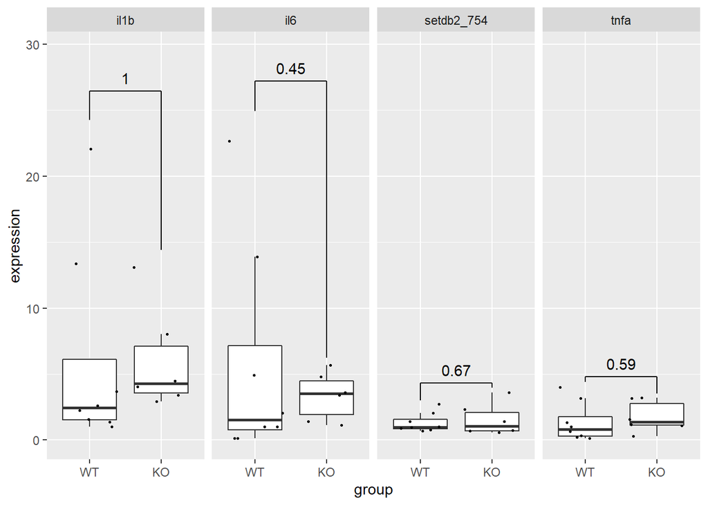

```r
ggplot(expression4,aes(x=group,y=expression)) +
  facet_wrap(.~target,ncol=5) +
  geom_boxplot(outlier.shape = NA) +
  geom_jitter(size = 0.5) +
  geom_segment(data=test,aes(x="WT",xend="KO",y=max.max*1.2,yend=max.max*1.2)) +
  geom_segment(data=test,aes(x="WT",xend="WT",y=WT.max*1.1,yend=max.max*1.2)) +
  geom_segment(data=test,aes(x="KO",xend="KO",y=KO.max*1.1,yend=max.max*1.2)) +
  coord_cartesian(ylim=c(0,max(expression4$expression)*1.3)) +
  geom_text(data=test, aes(x=1.5,y=max.max*1.2+1,label=ttest))
```

#### 棒グラフを描く

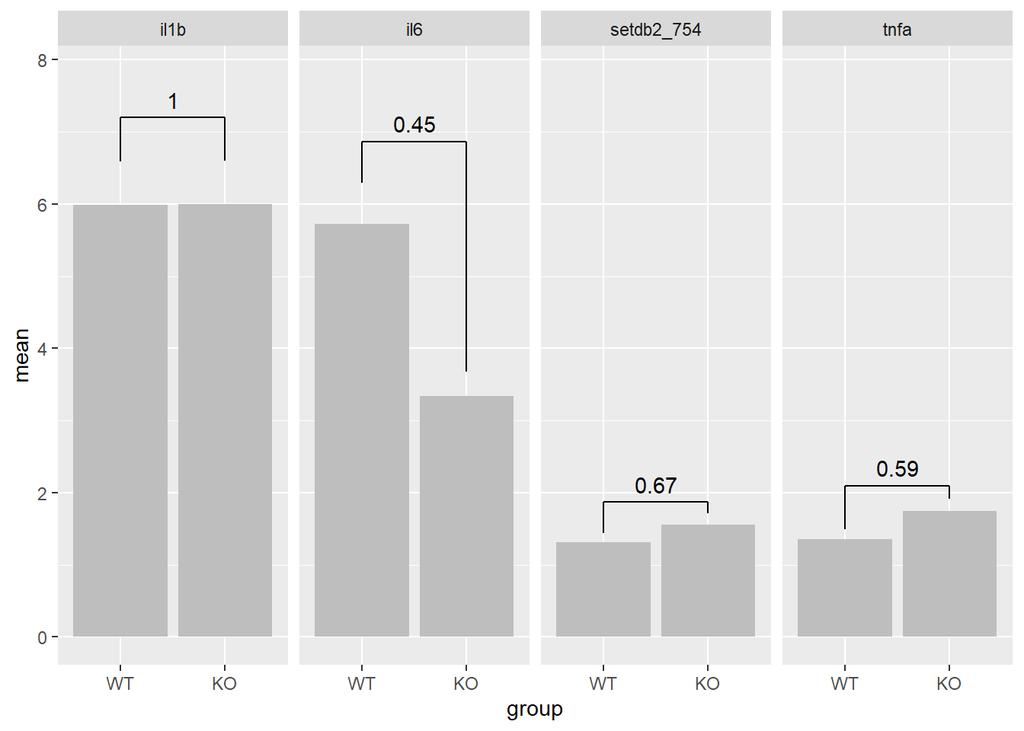

```r
ggplot(expression4) +
  facet_wrap(.~target,ncol=5) +
  geom_bar(data=expression.summary,aes(x=group,y=mean),stat="identity",fill="grey") +
  geom_segment(data=test,aes(x="WT",xend="KO",y=max.mean*1.2,yend=max.mean*1.2)) +
  geom_segment(data=test,aes(x="WT",xend="WT",y=WT.mean*1.1,yend=max.mean*1.2)) +
  geom_segment(data=test,aes(x="KO",xend="KO",y=KO.mean*1.1,yend=max.mean*1.2)) +
  coord_cartesian(ylim=c(0,max(expression.summary$mean)*1.3)) +
  geom_text(data=test, aes(x=1.5,y=max.mean*1.2+0.25,label=ttest))
```